# Amazon_sales_analysis

1. AMAZON SALES DATA ANALYSIS - 2025

   This beginner Python project explores a dataset of Amazon sales, including orders, prices, statuses and product categories.

### Objectives:

   - Load and explore the dataset
   - Clean and prepare the data
   - Analyse sales trends and product categories
   - Visualize data using graphs

     *Created using Python, Pandas, Matplotlib, and Seaborn,*
2. Import Libraries

```python
import pandas as pd
import matplotlib.pyplot as plt
import seaborn as sns

%matplotlib inline
```

3. Load the Dataset

```python
df = pd.read_csv('amazon_sales_data 2025 2.csv')
print(df.columns.tolist())
df.columns = df.columns.str.strip().str.lower()

df.head()
```

```
['Order ID', 'Date', 'Product', 'Category', 'Price', 'Status']
```

|  | order id | date | product | category | price | status |
| --- | --- | --- | --- | --- | --- | --- |
| 0 | ORD0001 | 14/03/2025 | Running Shoes | Footwear | 60 | Cancelled |
| 1 | ORD0002 | 20/03/2025 | Headphones | Electronics | 100 | Pending |
| 2 | ORD0003 | 15/02/2025 | Running Shoes | Footwear | 60 | Cancelled |
| 3 | ORD0004 | 19/02/2025 | Running Shoes | Footwear | 60 | Pending |
| 4 | ORD0005 | 10/03/2025 | Smartwatch | Electronics | 150 | Pending |

4. Data Cleaning & Formatting
   - Convert date to datetime format
   - check for missing values
   - handle any basic issues

```python
df['Date'] = pd.to_datetime(df['Date'], format='%d/%m/%Y')
df.isnull().sum()
df.fillna(0, inplace=True)
```

5. Exploratory Data Analysis (EDA) Let's explore key insights from the dataset, such as total sales, product performance, and status counts.

A. Total Sales

```python
print(df.columns.tolist())
df.columns = df.columns.str.strip()  # removes spaces at beginning/end
df.columns = df.columns.str.lower()  # make all names lowercase
print(df.columns.tolist())

total_sales = df['price'].sum()
print(f" Total Sales: £{total_sales}")
```

```
['Order ID', 'Date', 'Product', 'Category', 'Price', 'Status']
['order id', 'date', 'product', 'category', 'price', 'status']
 Total Sales: £85895
```

B. Order Status Count

```
status
Completed    88
Pending      85
Cancelled    77
Name: count, dtype: int64
```

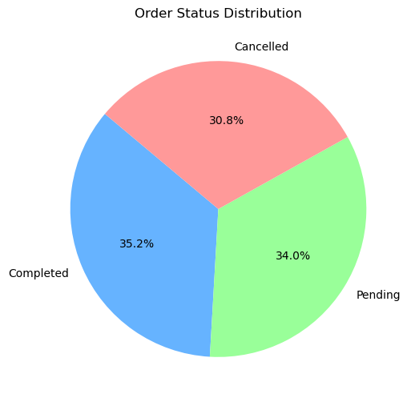

```python
df.columns = df.columns.str.strip()  # removes extra spaces
df.columns = df.columns.str.lower()  # makes all lowercase

status_counts = df['status'].value_counts()
print(status_counts)
plt.figure(figsize=(6,6))
status_counts.plot.pie(autopct='%1.1f%%', startangle=140, colors=['#66b3ff','#99ff99','#ff9999'])
plt.title('Order Status Distribution')
plt.ylabel('')
plt.show()
```

6. Top 5 Products by Sales

```
['order_id', 'date', 'product', 'category', 'price', 'status']
product
Refrigerator       28800
Laptop             19200
Smartphone         17500
Washing Machine     9600
Smartwatch          5100
Name: price, dtype: int64
```

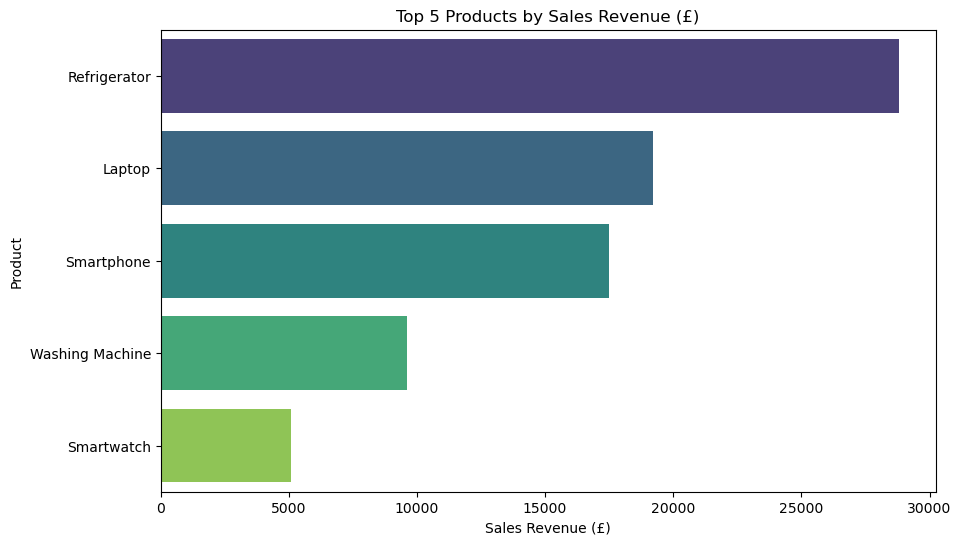

```python
print(df.columns.tolist())


top_products = df.groupby('product')['price'].sum().sort_values(ascending=False).head(5)

print(top_products)

import matplotlib.pyplot as plt
import seaborn as sns

# Bar plot for Top 5 Products by Sales
plt.figure(figsize=(10,6))
sns.barplot(x=top_products.values, y=top_products.index, palette="viridis")
plt.title("Top 5 Products by Sales Revenue (£)")
plt.xlabel("Sales Revenue (£)")
plt.ylabel("Product")
plt.show()
```

CONCLUSION

This analysis of the Amazon Sales Dataset for 2025 provides valuable insights into sales performance and customer order behavior.

The dataset was successfully loaded, cleaned, and prepared for analysis, including formatting dates and handling missing data. The total sales revenue across all products amounted to £85,895, indicating a strong overall sales performance. Order statuses showed a healthy distribution with 88 completed orders, but also a significant number of pending (85) and cancelled (77) orders, highlighting areas for potential improvement in order fulfillment. The top 5 products by total sales revenue are:

1.Refrigerator (£28,800) 2.Laptop (£19,200) 3.Smartphone (£17,500) 4.Washing Machine (£9,600) 5.Smartwatch (£5,100)

These high-performing products suggest key categories driving the majority of revenue, which could be prioritized for marketing and stock management.

The visualizations and data exploration provide a foundation for strategic decisions to enhance product offerings, improve order processing efficiency, and ultimately increase sales in future periods.